# MScA, Linear and Non-Linear Models (31010) Week 8: Workshop

© Yuri Balasanov, iLykei 2016

# 1 Deciding between fixed or random effects model

Decision about including a predictor into model as fixed or random effect is important and depends on the goal of the study and data collection process.

**Example**.  
Same treatment procedure is done by multiple hospitals. Then results representing success of treatment are collected from multiple patients within each hospital. Hospital is a factor in the study. Should it be considered fixed or random effects factor?

**Fixed effect argument**.

- Results may differ by hospital due to experience of clinicians, equipment, demographic variation and other reasons.
- These differences are the goal of the study.
- Data are collected from all hospitals of interest.
- Number of hospitals is not too large and will not saturate the model with dummy variables for each level of the factor.

To analyze differences between hospitals linear regression or ANOVA models can be estimated for each hospital separately or for all hospitals together with hospital being a categorical predictor.  
For example, ANOVA model can estimate specific intercept for each group of patients from the same hospital. Then utility test is used to decide if all hospitals have same group mean values, and if not contrasts can be used to identify hospitals with different results.

**Random effect argument**.

- Differences between hospital conditions is not primary goal of the study. The main goal is assessment of the treatment. Hospital is a kind of nuisance predictor.
- There are too many hospitals. So, it makes sense to treat them as population and consider random selection of hospitals from this population for study.

For example, in the same ANOVA framework random effect makes intercepts specific to each hospital realizations of the same random variable. Instead of estimating and predicting each of them the model estimates distribution of the population.  
Then instead of hypothesis about equivalence of all group mean values the test looks at equality to zero of the distribution of population intercepts.  
Individual hospital mean values can still be predicted as mean values of conditional posterior distribution explained within Bayesian framework.  
However, this predictions may be different from group mean values resulting from fixed effect models due to effect of shrinkage.

# 2 Simple Model with Random Effects

```r
suppressWarnings(library(faraway))
suppressWarnings(library(ggplot2))
suppressWarnings(library(lme4))
suppressWarnings(library(knitr))
```

## 2.1 Example with data on page 154.

```r
data(pulp)
pulp
```

```
##    bright operator
## 1    59.8        a
## 2    60.0        a
## 3    60.8        a
## 4    60.8        a
## 5    59.8        a
## 6    59.8        b
## 7    60.2        b
## 8    60.4        b
## 9    59.9        b
## 10   60.0        b
## 11   60.7        c
## 12   60.7        c
## 13   60.5        c
## 14   60.9        c
## 15   60.3        c
## 16   61.0        d
## 17   60.8        d
## 18   60.6        d
## 19   60.5        d
## 20   60.5        d
```

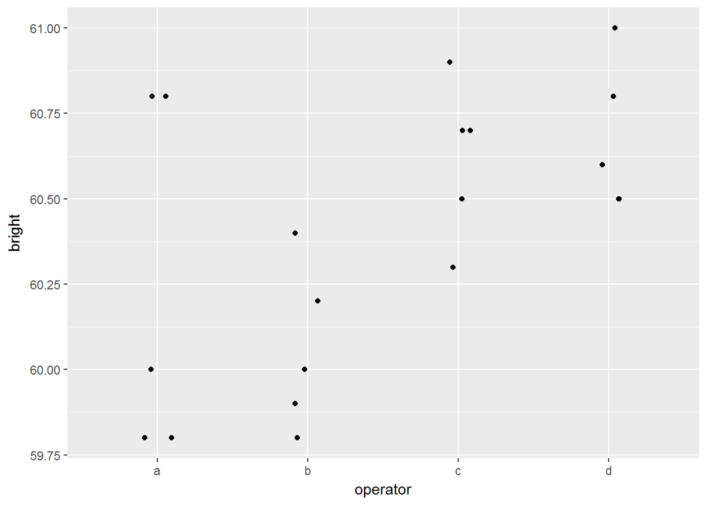

```r
ggplot(pulp, aes(x=operator,y=bright))+
  geom_point(position =position_jitter(width=0.1, height=0.0))
```

Argument `position_jitter` in `ggplot()` is used to avoid overplotting points on the graph.

Plot the data and show grand and group means.

Calculate means.

```r
grand<-mean(pulp$bright)
gr.a<-mean(subset(pulp,operator=="a")$bright)
gr.b<-mean(subset(pulp,operator=="b")$bright)
gr.c<-mean(subset(pulp,operator=="c")$bright)
gr.d<-mean(subset(pulp,operator=="d")$bright)
c(grand,gr.a,gr.b,gr.c,gr.d)
```

```
## [1] 60.40 60.24 60.06 60.62 60.68
```

Alternatively,

```r
aggregate(pulp$bright,by=list(pulp$operator),FUN=mean)
```

```
##   Group.1     x
## 1       a 60.24
## 2       b 60.06
## 3       c 60.62
## 4       d 60.68
```

Calculate group indices.

```r
(lev<-levels(pulp$operator))
```

```
## [1] "a" "b" "c" "d"
```

```r
(idx.1<-pulp$operator==lev[1])
```

```
##  [1]  TRUE  TRUE  TRUE  TRUE  TRUE FALSE FALSE FALSE FALSE FALSE FALSE
## [12] FALSE FALSE FALSE FALSE FALSE FALSE FALSE FALSE FALSE
```

```r
idx.2<-pulp$operator==lev[2]
idx.3<-pulp$operator==lev[3]
idx.4<-pulp$operator==lev[4]
```

Create matrix for plotting the data.

```r
#Matrix and column names
plotData<-matrix(NA,length(pulp$operator),2*length(lev))
(colnames(plotData)<-c(lev,paste("mean",lev,sep=".")))
```

```
## [1] "a"      "b"      "c"      "d"      "mean.a" "mean.b" "mean.c" "mean.d"
```

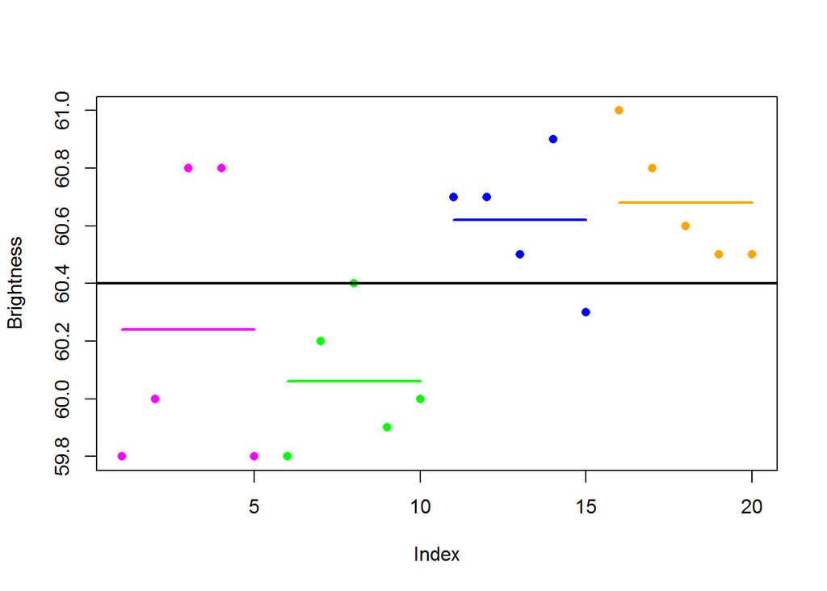

```r
#Grouped data
plotData[idx.1,1]<-pulp$bright[idx.1]
plotData[idx.2,2]<-pulp$bright[idx.2]
plotData[idx.3,3]<-pulp$bright[idx.3]
plotData[idx.4,4]<-pulp$bright[idx.4]

#Group means
plotData[idx.1,5]<-(idx.1*gr.a)[idx.1]
plotData[idx.2,6]<-(idx.2*gr.b)[idx.2]
plotData[idx.3,7]<-(idx.3*gr.c)[idx.3]
plotData[idx.4,8]<-(idx.4*gr.d)[idx.4]

#Plot
matplot(1:length(pulp$bright),plotData[,1:4],col=c("magenta","green","blue","orange"),
        pch=16,ylab="Brightness",xlab="Index")
lines(1:length(pulp$bright),plotData[,5],col="magenta",lwd=2)
lines(1:length(pulp$bright),plotData[,6],col="green",lwd=2)
lines(1:length(pulp$bright),plotData[,7],col="blue",lwd=2)
lines(1:length(pulp$bright),plotData[,8],col="orange",lwd=2)
abline(h=grand,col="black",lwd=2)
```

Model for these data within ANOVA framework is

$$y_{ij} = \mu_a + \beta_1 I_{[gr_b]} + \beta_2 I_{[gr_c]} + \beta_3 I_{[gr_d]} + \epsilon_{ij},$$
where $\mu_a$ is the group mean for operator $a$, indicators $I_{[gr_b]}, I_{[gr_c]}, I_{[gr_d]}$ are equal to 1 if observation comes from the corresponding operator and 0 otherwise and coefficients $\beta_i,~i=1,2,3$ are differences between group mean values of operators $b,c,d$ and group mean of operator $a$, i.e.
$$\mu_b=\mu_a+\beta_1,~\mu_c=\mu_a+\beta_2,~\mu_d=\mu_a+\beta_3.$$

Usual ANOVA breaks down sum of squares of brightness observations as:

$$\sum_{i=1}^4 \sum_{j=1}^5 (y_{ij}-\bar{y}_{\cdot \cdot})^2=\sum_{i=1}^4 \sum_{j=1}^5 (y_{ij}-\bar{y}_{i \cdot})^2 + \sum_{i=1}^4 \sum_{j=1}^5 (\bar{y}_{i \cdot}-\bar{y}_{\cdot \cdot})^2,$$
or
$$SST = SSE + SSM.$$

The last 2 sums of squares $SSE$ and $SSM$ are shown in ANOVA table with their respective degrees of freedom.  
Simplest model including random effects is

$$y_{ij} = \mu + \alpha_1 I_{[gr_b]} + \alpha_2 I_{[gr_c]} + \alpha_3 I_{[gr_d]} + \epsilon_{ij},$$
where grouping is still by operator, coefficients $\alpha_1,\alpha_2,\alpha_3$ are realizations of random variable $A \sim N(0,\sigma_{\alpha})$ and random variables $A, \epsilon_{ij}$ are independent.

Such model is defined by formula `bright~1+(1|operator)`.

Null hypothesis of ANOVA is $H_0:~\beta_1=\beta_2=\beta_3=0$, but for random effects model prediction is done for $\sigma_{\alpha}$ and the null hypothesis is $H_0:~\sigma_{\alpha}=0$.

### 2.1.1 Estimate fixed effects by fitting linear model and ANOVA.

Linear model with categorical predictors assigns fixed factors to group means.

```r
md.fixed<-lm(bright~operator,pulp)
summary(md.fixed)
```

```
##
## Call:
## lm(formula = bright ~ operator, data = pulp)
##
## Residuals:
##    Min     1Q Median     3Q    Max
## -0.440 -0.195 -0.070  0.175  0.560
##
## Coefficients:
##             Estimate Std. Error t value Pr(>|t|)
## (Intercept)  60.2400     0.1458 413.243   <2e-16 ***
## operatorb    -0.1800     0.2062  -0.873   0.3955
## operatorc     0.3800     0.2062   1.843   0.0839 .
## operatord     0.4400     0.2062   2.134   0.0486 *
## ---
## Signif. codes:  0 '***' 0.001 '**' 0.01 '*' 0.05 '.' 0.1 ' ' 1
##
## Residual standard error: 0.326 on 16 degrees of freedom
## Multiple R-squared:  0.4408, Adjusted R-squared:  0.3359
## F-statistic: 4.204 on 3 and 16 DF,  p-value: 0.02261
```

```r
(md.fixed.anova<-anova(md.fixed))
```

```
## Analysis of Variance Table
##
## Response: bright
##           Df Sum Sq Mean Sq F value  Pr(>F)
## operator   3   1.34 0.44667  4.2039 0.02261 *
## Residuals 16   1.70 0.10625
## ---
## Signif. codes:  0 '***' 0.001 '**' 0.01 '*' 0.05 '.' 0.1 ' ' 1
```

Calculate sums of squares returned by ANOVA table directly from the data.

(Skipped Code)

```r
c(SSE=SSE,SSM=SSM,SST=SST)
```

```
##  SSE  SSM  SST
## 1.70 1.34 3.04
```

```r
SSM/3
```

```
## [1] 0.4466667
```

```r
SSE/16
```

```
## [1] 0.10625
```

ANOVA table shows that operator effect is significant.

What are the effects of the four operators?

```r
(fixedEffects<-c(gr.a,gr.b,gr.c,gr.d)-grand)
```

```
## [1] -0.16 -0.34  0.22  0.28
```

Here fixed effects are centered by grand mean. They can also be centered by mean value of vector `c(gr.a,gr.b,gr.c,gr.d)`. In case when all groups have the same numbers of elements result is the same.

Another way of calculating group means and interpretation of coefficients:

```r
(groupMeans<-c(md.fixed$coefficients[1],md.fixed$coefficients[1]+md.fixed$coefficients[-1]))
```

```
## (Intercept)   operatorb   operatorc   operatord
##       60.24       60.06       60.62       60.68
```

What does the linear model predict?

```r
(md.fixed.predict<-predict(md.fixed))
```

```
##     1     2     3     4     5     6     7     8     9    10    11    12
## 60.24 60.24 60.24 60.24 60.24 60.06 60.06 60.06 60.06 60.06 60.62 60.62
##    13    14    15    16    17    18    19    20
## 60.62 60.62 60.62 60.68 60.68 60.68 60.68 60.68
```

or

```r
(unique(md.fixed.predict))
```

```
## [1] 60.24 60.06 60.62 60.68
```

This are exactly group mean values.

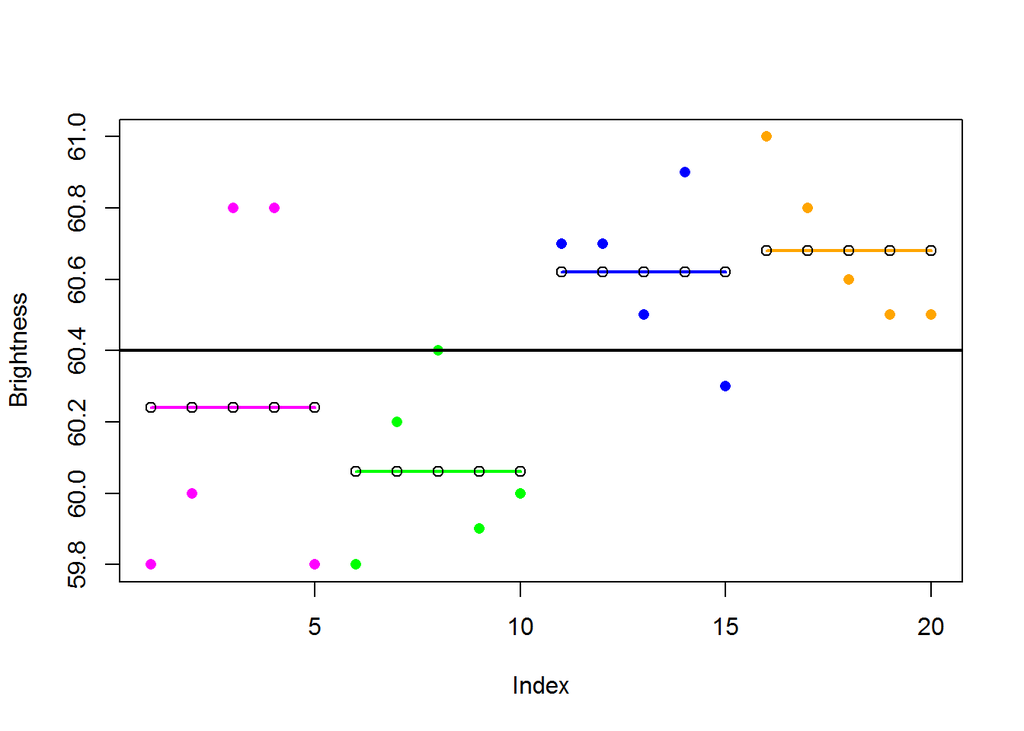

```r
matplot(1:length(pulp$bright),plotData[,1:4],col=c("magenta","green","blue","orange"),
        pch=16,ylab="Brightness",xlab="Index")
lines(1:length(pulp$bright),plotData[,5],col="magenta",lwd=2)
lines(1:length(pulp$bright),plotData[,6],col="green",lwd=2)
lines(1:length(pulp$bright),plotData[,7],col="blue",lwd=2)
lines(1:length(pulp$bright),plotData[,8],col="orange",lwd=2)
abline(h=grand,col="black",lwd=2)
points(1:length(pulp$bright),md.fixed.predict)
```

Obviously, predicted values, as well as the fitted values, are the group means for the corresponding groups.

**What is the null hypothesis that ANOVA tests?**

#### 2.1.1.1 Fit random effects model.

Recall ANOVA table.

```r
md.fixed.anova
```

```
## Analysis of Variance Table
##
## Response: bright
##           Df Sum Sq Mean Sq F value  Pr(>F)
## operator   3   1.34 0.44667  4.2039 0.02261 *
## Residuals 16   1.70 0.10625
## ---
## Signif. codes:  0 '***' 0.001 '**' 0.01 '*' 0.05 '.' 0.1 ' ' 1
```

```r
md.fixed.anova$`Mean Sq`
```

```
## [1] 0.4466667 0.1062500
```

If operator effects are treated as a sample from population of random effects then the variance of operator effect replaces group mean values of ANOVA as parameters.

Fit random effects model using `lmer()`.

```r
md.random<-lmerTest::lmer(bright~1+(1|operator),pulp)
summary(md.random)
```

```
## summary from lme4 is returned
## some computational error has occurred in lmerTest
```

```
## Linear mixed model fit by REML ['lmerMod']
## Formula: bright ~ 1 + (1 | operator)
##    Data: pulp
##
## REML criterion at convergence: 18.6
##
## Scaled residuals:
##     Min      1Q  Median      3Q     Max
## -1.4666 -0.7595 -0.1244  0.6281  1.6012
##
## Random effects:
##  Groups   Name        Variance Std.Dev.
##  operator (Intercept) 0.06808  0.2609
##  Residual             0.10625  0.3260
## Number of obs: 20, groups:  operator, 4
##
## Fixed effects:
##             Estimate Std. Error t value
## (Intercept)  60.4000     0.1494   404.2
```

The formula syntax `(1|operator)` means that the data are grouped by operator (4 groups) and mean value within each group is constant.

The model has both fixed and random effects.

One fixed effect - intercept, which is the same as the grand mean.

The random effect block of the output looks like ANOVA table.  
Residual variance of random effects is the same as residual variance (residual sum of squares, divided by 16 degrees of freedom) of ANOVA. This means that residuals are the same.  
But the variance of random operator effect is 0.0680833 and different from the operator variance of ANOVA which is calculated as

$$\frac{1}{n_{gr}-1}\sum (\hat{y}_i-\bar{y})^2$$
.

```r
(md.random.varCorr<-as.data.frame(VarCorr(md.random)))
```

```
##        grp        var1 var2       vcov     sdcor
## 1 operator (Intercept) <NA> 0.06808333 0.2609278
## 2 Residual        <NA> <NA> 0.10625000 0.3259601
```

```r
#Variance of random effect
md.random.varCorr$vcov[1]
```

```
## [1] 0.06808333
```

```r
#Variance of residuals
md.random.varCorr$vcov[2]
```

```
## [1] 0.10625
```

Plot the data and the predictions.

```r
(md.random.predict<-predict(md.random))
```

```
##        1        2        3        4        5        6        7        8
## 60.27806 60.27806 60.27806 60.27806 60.27806 60.14088 60.14088 60.14088
##        9       10       11       12       13       14       15       16
## 60.14088 60.14088 60.56767 60.56767 60.56767 60.56767 60.56767 60.61340
##       17       18       19       20
## 60.61340 60.61340 60.61340 60.61340
```

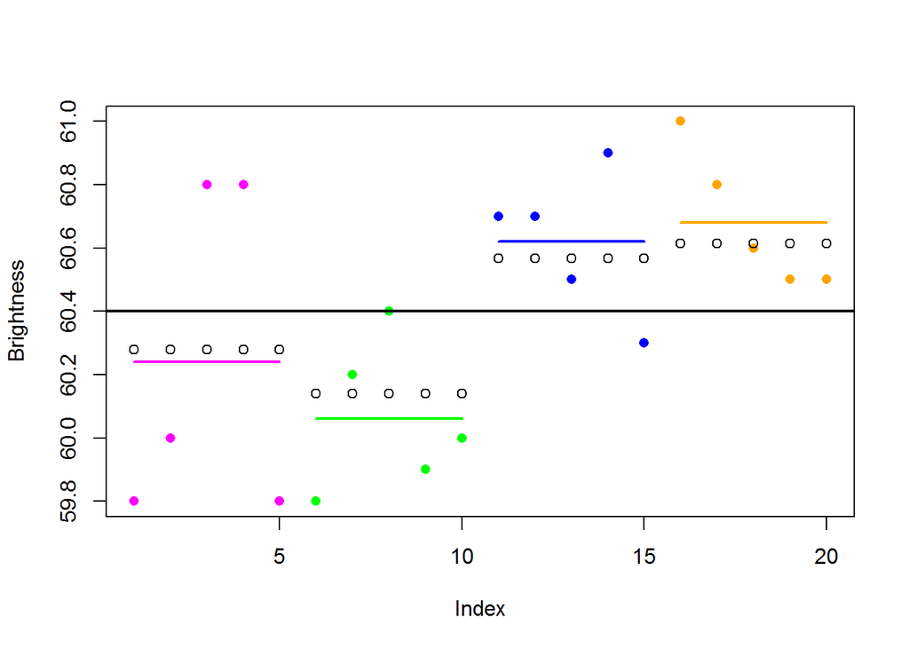

```r
matplot(1:length(pulp$bright),plotData[,1:4],col=c("magenta","green","blue","orange"),
        pch=16,ylab="Brightness",xlab="Index")
lines(1:length(pulp$bright),plotData[,5],col="magenta",lwd=2)
lines(1:length(pulp$bright),plotData[,6],col="green",lwd=2)
lines(1:length(pulp$bright),plotData[,7],col="blue",lwd=2)
lines(1:length(pulp$bright),plotData[,8],col="orange",lwd=2)
abline(h=grand,col="black",lwd=2)
points(1:length(pulp$bright),md.random.predict)
```

The differences between the group means and the fitted values are:

```r
fitted(md.fixed)-fitted(md.random)
```

```
##           1           2           3           4           5           6
## -0.03805970 -0.03805970 -0.03805970 -0.03805970 -0.03805970 -0.08087687
##           7           8           9          10          11          12
## -0.08087687 -0.08087687 -0.08087687 -0.08087687  0.05233209  0.05233209
##          13          14          15          16          17          18
##  0.05233209  0.05233209  0.05233209  0.06660448  0.06660448  0.06660448
##          19          20
##  0.06660448  0.06660448
```

The differences between the grand mean and the fitted values are:

```r
fitted(md.random)-grand
```

```
##          1          2          3          4          5          6
## -0.1219403 -0.1219403 -0.1219403 -0.1219403 -0.1219403 -0.2591231
##          7          8          9         10         11         12
## -0.2591231 -0.2591231 -0.2591231 -0.2591231  0.1676679  0.1676679
##         13         14         15         16         17         18
##  0.1676679  0.1676679  0.1676679  0.2133955  0.2133955  0.2133955
##         19         20
##  0.2133955  0.2133955
```

or

```r
unique(fitted(md.random)-grand)
```

```
## [1] -0.1219403 -0.2591231  0.1676679  0.2133955
```

Compare them with the random effects

```r
(randomEffects<-ranef(md.random))
```

```
## $operator
##   (Intercept)
## a  -0.1219403
## b  -0.2591231
## c   0.1676679
## d   0.2133955
```

Ratio of fixed effects to random effects is constant.

```r
fixedEffects/randomEffects$operator
```

```
##   (Intercept)
## a    1.312118
## b    1.312118
## c    1.312118
## d    1.312118
```

**Random effects are deviations of constant group levels from the grand mean.**  
**Ratio of fixed effects to random effects is constant.**

Predictions of model with random effects show **shrinkage** characterized by the ratio of fixed effects to random effects.

To reproduce variance of random effect by operator use [this post](https://stats.stackexchange.com/questions/68106/understanding-the-variance-of-random-effects-in-lmer-models):

```r
suppressWarnings(library(arm)) #function se.ranef()
var(randomEffects$operator)+sum(se.ranef(md.random)$operator^2)/4
```

```
##             (Intercept)
## (Intercept)  0.06808333
```

$$\sigma_{\alpha}^2 = \frac{1}{3}\sum_{i=1}^4 \hat{\alpha}_i^2 + \frac{1}{4}\sum_{i=1}^4 V[\hat{\alpha}_i].$$
he first term represents variance between groups and second - within groups.

**Compare:**

1. Number of parameters in each model
- For `lm()`: intercept, 3 slopes for dummy variables, variance of residuals;
- For `lmer()`: intercept, variance of the random effect, variance of residuals
2. Summary statistics of residuals

```r
md.fixed.residuals<-summary(md.fixed)$residuals
md.random.residuals<-summary(md.random)$residuals
```

```
## summary from lme4 is returned
## some computational error has occurred in lmerTest
```

```r
cbind(fixedEffectsResiduals=md.fixed.residuals,randomEffectsResiduals=md.random.residuals)
```

```
##    fixedEffectsResiduals randomEffectsResiduals
## 1                  -0.44            -1.46662021
## 2                  -0.24            -0.85304822
## 3                   0.56             1.60123974
## 4                   0.56             1.60123974
## 5                  -0.44            -1.46662021
## 6                  -0.26            -1.04576249
## 7                   0.14             0.18138149
## 8                   0.34             0.79495348
## 9                  -0.16            -0.73897649
## 10                 -0.06            -0.43219050
## 11                  0.08             0.40597632
## 12                  0.08             0.40597632
## 13                 -0.12            -0.20759567
## 14                  0.28             1.01954831
## 15                 -0.32            -0.82116766
## 16                  0.32             1.18604840
## 17                  0.12             0.57247641
## 18                 -0.08            -0.04109558
## 19                 -0.18            -0.34788158
## 20                 -0.18            -0.34788158
```

```r
cbind(summary(md.fixed.residuals),summary(md.random.residuals))
```

```
##               [,1]       [,2]
## Min.    -4.400e-01 -1.467e+00
## 1st Qu. -1.950e-01 -7.595e-01
## Median  -7.000e-02 -1.243e-01
## Mean     1.422e-17 -8.716e-15
## 3rd Qu.  1.750e-01  6.281e-01
## Max.     5.600e-01  1.601e+00
```

Why residuals are so different?

Compare the random effects residuals with Pearson residuals.

```r
cbind(fixedEffectsRes=md.fixed.residuals,
      randomEffectsRes=md.random.residuals,
      randomEffectsResPearson=residuals(md.random,type="pearson",scale=TRUE))
```

```
##    fixedEffectsRes randomEffectsRes randomEffectsResPearson
## 1            -0.44      -1.46662021             -1.46662021
## 2            -0.24      -0.85304822             -0.85304822
## 3             0.56       1.60123974              1.60123974
## 4             0.56       1.60123974              1.60123974
## 5            -0.44      -1.46662021             -1.46662021
## 6            -0.26      -1.04576249             -1.04576249
## 7             0.14       0.18138149              0.18138149
## 8             0.34       0.79495348              0.79495348
## 9            -0.16      -0.73897649             -0.73897649
## 10           -0.06      -0.43219050             -0.43219050
## 11            0.08       0.40597632              0.40597632
## 12            0.08       0.40597632              0.40597632
## 13           -0.12      -0.20759567             -0.20759567
## 14            0.28       1.01954831              1.01954831
## 15           -0.32      -0.82116766             -0.82116766
## 16            0.32       1.18604840              1.18604840
## 17            0.12       0.57247641              0.57247641
## 18           -0.08      -0.04109558             -0.04109558
## 19           -0.18      -0.34788158             -0.34788158
## 20           -0.18      -0.34788158             -0.34788158
```

For `lme()` Pearson residuals are scaled by the standard deviation: $\frac{Observation - Mean}{Sigma}$

**What is the null hypothesis for random effects model?**

# 3 Example

## 3.1 Random intercept model

The model for random intercept is

$$y_{ij}=\mu+\gamma_i+\epsilon_{ij},$$
where $i=0,1$, $\gamma_0=\gamma_F$ distributed as $Norm(\mu_F,\sigma_F)$ if Gen=F, $\gamma_1=\gamma_M$ distributed as $Norm(\mu_M,\sigma_M)$ if Gen=M.

Simulate data and analyze them using `lmer()` from `lme4` for the following situation:

Marketing conversion analysis for a product shows that probability of conversion (of a visitor into a registering or paying customer) depends on age and gender.  
Probability of success measured for 3 age groups: 20-30, 30-40 and 40-50 and within each age group the probability is differentiated by gender.  
There were 100 participants of each gender in every age group.  
The results are presented in the following table

```r
Marketing.Probabilities.Data<-data.frame(cbind(Age.20.30=c(.7,.55,.1,.2),
                                               Age.30.40=c(.5,.4,.1,.2),
                                               Age.40.50=c(.3,.2,.07,.09)))
rownames(Marketing.Probabilities.Data)<-c("F.mean","M.mean","F.sd","M.sd")
kable(Marketing.Probabilities.Data)
```

|  | Age.20.30 | Age.30.40 | Age.40.50 |
| --- | --- | --- | --- |
| F.mean | 0.70 | 0.5 | 0.30 |
| M.mean | 0.55 | 0.4 | 0.20 |
| F.sd | 0.10 | 0.1 | 0.07 |
| M.sd | 0.20 | 0.2 | 0.09 |

Overall error of observation $\epsilon$ has normal distribution with zero mean and $\sigma_\epsilon=.02$.

Simulate data frame consistent with these observations and reproduce the analysis. Use the seed:

```r
set.seed(49274)
```

(Skipped Code)

```r
head(Marketing.Probabilities)
```

```
##        Age Gender Probability
## 1 Age20-30      F   0.7499608
## 2 Age20-30      F   0.7656688
## 3 Age20-30      F   0.7724233
## 4 Age20-30      F   0.6684627
## 5 Age20-30      F   0.7915936
## 6 Age20-30      F   0.8181987
```

Calculate age group means and standard deviations

```r
Gender.Group.Means<-aggregate(Marketing.Probabilities$Probability,
                              list(Marketing.Probabilities$Age,
                                   Marketing.Probabilities$Gender),FUN=mean)
Gender.Group.Sd<-aggregate(Marketing.Probabilities$Probability,
                              list(Marketing.Probabilities$Age,
                                   Marketing.Probabilities$Gender),FUN=sd)

Mean.Sd.Table<-data.frame(Age.20.30=c(Gender.Group.Means[c(1,4),3],
                                      Gender.Group.Sd[c(1,4),3]),
                          Age.30.40=c(Gender.Group.Means[c(2,5),3],Gender.Group.Sd[c(2,5),3]),
                          Age.40.50=c(Gender.Group.Means[c(3,6),3],Gender.Group.Sd[c(3,6),3]))

rownames(Mean.Sd.Table)<-c("F.mean","M.mean","F.sd","M.sd")
```

Create a table to check if your simulation is consistent with the real study results.

```r
kable(Mean.Sd.Table)
```

|  | Age.20.30 | Age.30.40 | Age.40.50 |
| --- | --- | --- | --- |
| F.mean | 0.7049620 | 0.5035082 | 0.3068780 |
| M.mean | 0.5577594 | 0.4257460 | 0.2083549 |
| F.sd | 0.1046091 | 0.1100951 | 0.0773691 |
| M.sd | 0.2074638 | 0.1868829 | 0.1009455 |

Fit linear model explaining Probability by Age `Model.by.Age` and by Age + Gender `Model.by.Age.Gender`.  
Analyze the summary of each model, compare them.  
Check AIC for each of the models.  
Analyze and compare ANOVA tables for the two models.

## 3.2 Models grouped by age

```r
library(lmerTest)
```

Library `lmerTest` augments `Lmer` model with p-value of variance parameter (function `rand()`).

### 3.2.1 Linear model

(Skipped Code)

```r
anova(Model.by.Age)
```

```
## Analysis of Variance Table
##
## Response: Probability
##            Df Sum Sq Mean Sq F value    Pr(>F)
## Age         2 14.023  7.0113  310.64 < 2.2e-16 ***
## Residuals 597 13.475  0.0226
## ---
## Signif. codes:  0 '***' 0.001 '**' 0.01 '*' 0.05 '.' 0.1 ' ' 1
```

### 3.2.2 Random effects model

Fit `lmer()` to `Probability~Age` (`Lmer.by.Age`).

(Skipped Code)

Compare the outputs.  
Explain the value of fixed effect returned by `lmer()`.  
Calculate random effects of `Lmer.by.Age` manually and using `ranef()`.  
Calculate fixed effects of `Model.by.Age`.  
Compare variances of fixed effects and random effects the output of `lmer()`  
Do you observe shrinkage?

(Skipped Code)

## 3.3 Models grouped by age and gender

### 3.3.1 Linear model

(Skipped Code)

```r
#Skipped
summary(Model.by.Age.Gender)
```

```r
anova(Model.by.Age.Gender)
```

```
## Analysis of Variance Table
##
## Response: Probability
##            Df  Sum Sq Mean Sq F value    Pr(>F)
## Age         2 14.0226  7.0113 356.228 < 2.2e-16 ***
## Gender      1  1.7441  1.7441  88.613 < 2.2e-16 ***
## Residuals 596 11.7305  0.0197
## ---
## Signif. codes:  0 '***' 0.001 '**' 0.01 '*' 0.05 '.' 0.1 ' ' 1
```

### 3.3.2 Random effects model

(Skipped Code)

Compare the outputs.  
Explain the value of fixed effect returned by `lmer()`.  
Calculate random effects of `Lmer.by.Age` manually and using `ranef()`.  
Explain results obtained using both ways.

(Skipped Code)

## 3.4 Random effects model with interaction

Fit `lmer()` to the formula with interaction between `Age` and `Gender` using the notation `(1|g1/g2)` or equivalently `(1|g1)+(1|g1:g2)`

```r
#Lmer.by.Age.Over.Gender<-lmer(Probability~(1|Age/Gender),data=Marketing.Probabilities)
Lmer.by.Age.Over.Gender<-lmer(Probability~(1|Age)+(1|Age:Gender),data=Marketing.Probabilities)
summary(Lmer.by.Age.Over.Gender)
```

```
## summary from lme4 is returned
## some computational error has occurred in lmerTest
```

```
## Linear mixed model fit by REML ['lmerMod']
## Formula: Probability ~ (1 | Age) + (1 | Age:Gender)
##    Data: Marketing.Probabilities
##
## REML criterion at convergence: -629
##
## Scaled residuals:
##     Min      1Q  Median      3Q     Max
## -3.4479 -0.5396 -0.0329  0.5554  3.6846
##
## Random effects:
##  Groups     Name        Variance Std.Dev.
##  Age:Gender (Intercept) 0.006042 0.07773
##  Age        (Intercept) 0.031938 0.17871
##  Residual               0.019534 0.13977
## Number of obs: 600, groups:  Age:Gender, 6; Age, 3
##
## Fixed effects:
##             Estimate Std. Error t value
## (Intercept)   0.4512     0.1081   4.174
```

```r
ranef(Lmer.by.Age.Over.Gender)
```

```
## $`Age:Gender`
##            (Intercept)
## Age20-30:F  0.08682066
## Age20-30:M -0.05577149
## Age30-40:F  0.03882029
## Age30-40:M -0.03650646
## Age40-50:F  0.03103723
## Age40-50:M -0.06440023
##
## $Age
##          (Intercept)
## Age20-30  0.16413275
## Age30-40  0.01223137
## Age40-50 -0.17636412
```

```r
rand(Lmer.by.Age.Over.Gender)
```

```
## Analysis of Random effects Table:
##            Chi.sq Chi.DF p.value
## Age           3.3      1    0.07 .
## Age:Gender   75.8      1  <2e-16 ***
## ---
## Signif. codes:  0 '***' 0.001 '**' 0.01 '*' 0.05 '.' 0.1 ' ' 1
```

**Is interaction significant?**